# Deaths related to the Volkswagen defeat devices

# 1 Introduction

This report attempts to reproduce analyses conducted by the New York Times, Vox, Mother Jones, and the Associated Press to determine the number of deaths associated with the Volkswagen defeat devices.

Relevant statistics used in some of the analyses:

- Approximate number of affected Volkswagen vehicles in the US: [482000](http://yosemite.epa.gov/opa/admpress.nsf/6424ac1caa800aab85257359003f5337/dfc8e33b5ab162b985257ec40057813b!OpenDocument) (source: US EPA)
- Approximate number of affected Volkswagen vehicles in California: [50000](http://www.arb.ca.gov/newsrel/in_use_compliance_letter.htm/) (source: California Air Resources Board)
- Average number of miles driven per year in the US: [11244](http://www.afdc.energy.gov/data/10309/) (source: US Department of Energy)
- EPA Tier 2 Bin 5 standard at useful life: [0.07 grams / mile](http://www3.epa.gov/otaq/standards/light-duty/tier2stds.htm) (source: US EPA)
- EPA Tier 2 Bin 5 standard at 50,000 miles: [0.05 grams / mile](http://www3.epa.gov/otaq/standards/light-duty/tier2stds.htm) (source: US EPA)
- Amount the affected Volkswagen vehicles exceeded the US EPA standards of 0.07 for NOx emissions: [15-35 times](http://www.theicct.org/news/epas-notice-violation-clean-air-act-volkswagen-press-statement) (source: The International Council on Clean Transportation)

# 2 New York Times

[Article link](http://www.nytimes.com/2015/09/29/upshot/how-many-deaths-did-volkswagens-deception-cause-in-us.html)

## 2.1 Estimate 1: Margot Sanger-Katz and John Schwartz

The authors estimated the number of affected vehicles in the US to be approximately 460,000 by excluding cars sold in July and 2016 models. They estimated the number of miles driven by affected cars to be 23,463,225,312 and the excess NOx to be 46,000 tons. The number of deaths, 106, was obtained using estimates from the Dechenes et al. working paper cited in the article, which estimated the benefits of reducing NOx from power plant emissions.

## 2.2 Estimate 2: Noelle Eckley Selin

This estimate was obtained using the same number of miles and estimated excess tons of NOx as the Sanger-Katz/Schwartz estimate. To obtain the estimated number of deaths, they used the estimated increase in deaths per ton of NOx related to particulate matter (PM) from the EPA technical support document “Estimating the Benefit per Ton of Reducing PM2.5 Precursors from 17 Sectors”.

# 3 Vox

[Article link](http://www.vox.com/2015/9/23/9383641/volkswagen-scandal-pollution/)

The Vox analysis estimated between 5,800 and 14,200 excess tons of NOx were emitted per year, by assuming that each vehicle drove on average 11,244 miles per year and the NOx emissions were 15-35 times the EPA standard of 0.07 grams per mile.

To estimate the number of deaths, they used the estimated increase in deaths per ton of NOx related to particulate matter (PM) from the EPA technical support document “Estimating the Benefit per Ton of Reducing PM2.5 Precursors from 17 Sectors”. This document provided two estimates: 0.00085 deaths per ton of NOx and 0.0019 deaths per ton of NOx. The authors estimated 5-27 deaths per year in the US were related to the affected Volkswagen vehicles. If we assume that the emissions were over 6 years (to match estimates from Mother Jones), the estimated deaths range from 30-162 in the US.

# 4 Mother Jones

[Article link](http://www.motherjones.com/kevin-drum/2015/09/spreadsheet-day-how-many-people-did-vw-kill/)

The Mother Jones analysis assumed that the number of affected vehicles on the road increased from 2009 through 2015, since Model Years 2009-2015 were impacted. Assuming an average of 12000 miles were driven per year and their analysis, I estimate a total of 16.6 billion miles driven by affected vehicles in the US.

They assumed that vehicles were 30 times the EPA limit of 0.07. To estimate the number of deaths, they used 0.0044 deaths per ton of NOx, which is derived from the range of deaths per ton of NOx related to ozone exposure of 0.0019-0.0095 from Mauzerall et al. (2005). This gives a point estimate of 17 deaths in California, with 170 deaths (range of 73-364 deaths) in the US, by assuming California has 1/10 of the US population.

# 5 Associated Press

[Article link](http://bigstory.ap.org/article/a6925f0af82e44aaa1a1ed4b55d030f6/ap-analysis-dozens-deaths-likely-vw-pollution-dodge)

Little information was provided about the assumptions used in the AP analysis. They reported 16-94 deaths over 7 years.

# 6 Significance article

## 6.1 Table of estimates

| Source | Miles (billions) | Amount NOx exceed limit | Excess NOx (tons) | Deaths per ton of NOx | Ambient pollutant causing death | Total US Deaths |
| --- | --- | --- | --- | --- | --- | --- |
| New York Times: MSK-JS | 23 | 40 | 46000 |  | All from power plants | 106 |
| New York Times: Selin | 23 | 40 | 46000 | 0.00085 | PM2.5 | 39 |
| Vox | 33 | 15-35 | (35128-85310) | 0.00085-0.0019 | PM2.5 | (30-162) |
| Mother Jones | 17 | 30 | 38334 | 0.0019-0.0095 | ozone | (73-364) |
| Associated Press | NA | NA | NA | NA | NA | (16-94) |

## 6.2 Uncertainty simulation

### 6.2.1 Histogram of all results

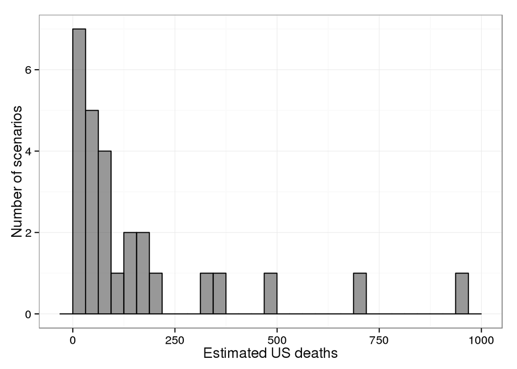

### 6.2.2 Table of selected simulation results

| Miles (billions) | Amount NOx exceed limit | Deaths per ton of NOx | Total US Deaths |
| --- | --- | --- | --- |
| 17 | 30 | 0.0019 | 72 |
| 33 | 30 | 0.0019 | 140 |
| 17 | 40 | 0.0019 | 97 |
| 17 | 30 | 0.0095 | 361 |